Tholonia - 026-C4-IChing  
The Existential Mechanics of Awareness  
Duncan Stroud  
Published: January 15, 2020  
Updated: Updated: Mar 26, 2026 v8.0.89  
Welkin Wall Publishing  
ISBN-10:  
ISBN-13: 978-1-6780-2532-8  
Copyright ©2020 Duncan Stroud CC BY-NC-SA 4.0

# Appendix C4: Tholonic Recursion and the I Ching

###### Ancient binary wisdom and modern tholonic mathematics

##### **Synopsis:** The binary nature of tholonic recursion connects naturally to the I Ching, which Leibniz himself recognised as a mirror of his independently developed binary arithmetic. The 64 hexagrams map precisely onto the three tholonic axes — Growth (Increase–Duration), Perfection (Before Completion–After Completion), and Refinement (Decrease–Influence) — with each axis dividing the hexagrams into symmetrical segments. The central concept of the Path of Equilibrium (*The Passage*) is shown to reflect universal philosophical traditions from Buddhism’s Middle Way to Taoism’s wu-wei, and is embodied in the hexagram pair Peace and Standstill. This appendix should be read alongside the companion volumes *Introduction to the Tholonic I Ching* and *The Tholonic I Ching*.

##### **Keywords:** I Ching, hexagrams, binary, Leibniz, tholonic recursion, Growth, Perfection, Refinement, Path of Equilibrium, The Passage, Peace, Standstill, Middle Way

### Binary Symbolism and the I Ching Connection

*Note: A much deeper exploration into the I Ching and the Thologram is covered in the book “Introduction to the Tholonic I Ching”. Additionally, the I Ching itself has been reinterpreted through the Tholonic lens in the book “The Tholonic I Ching”.*

The symbolism inherent in this recursive process, which is based explicitly on exponents of 2, naturally corresponds to a binary system, making it deeply connected to the symbolism found in the I Ching, itself fundamentally binary in nature. This connection between the ancient wisdom of the I Ching and mathematical symbolism has a significant historical precedent. Rather than viewing the Tholonic I Ching as an entirely new concept, it should be seen as a direct continuation and expansion of earlier explorations, specifically the groundbreaking work of Gottfried Wilhelm Leibniz, who himself studied the I Ching extensively.

Leibniz was first introduced to the I Ching in 1697 through correspondence with Father Joachim Bouvet, a French Jesuit missionary stationed in China. Bouvet’s letters included detailed diagrams of the 64 hexagrams and explanations of their meanings. This correspondence allowed Leibniz to recognize immediately the remarkable alignment between the system of broken and unbroken lines used in the I Ching and the binary arithmetic system that he himself had independently developed several years earlier.

Leibniz was deeply fascinated by this discovery and elaborated on it in his influential essay, *Explication de l’Arithmétique Binaire* (1703). He regarded this discovery as profound evidence of a universal truth that transcended cultural boundaries. For Leibniz, it validated both his mathematical explorations and his broader philosophical and theological beliefs.

Indeed, Leibniz’s binary system was fundamentally rooted in philosophical and theological ideas rather than purely practical mathematical applications. Leibniz perceived binary arithmetic as symbolic of divine creation itself. In his interpretation, the number “1” represented unity or God, and the number “0” represented nothingness. This binary opposition mirrored his philosophical conviction that God created everything out of nothing (*creatio ex nihilo*). Thus, Leibniz saw his binary arithmetic as the perfect mathematical representation of creation itself. This philosophical and theological dimension was central to Leibniz’s thinking about binary arithmetic, which, at the time, had not yet found practical applications. It was only centuries later, through the works of figures like George Boole and Claude Shannon, that binary arithmetic became central to communications and computing technology. For Leibniz himself, the binary system was primarily a philosophical and theological tool and a symbolic framework for understanding creation and illustrating the harmony between mathematics, philosophy, and religion.

In a letter to Duke Rudolf August of Brunswick in 1697, Leibniz explained clearly the spiritual essence of his binary arithmetic:

> *“The essence of my binary arithmetic is that I use no characters other than 0 and 1, and when reaching 2, I start again… This resembles creation ex nihilo, because all numbers are created from 1 and 0, just as all beings are created by God (the Unity) from nothing.”*

The Tholonic I Ching presented here aims explicitly to formalize and further develop the insights that Leibniz initially realized. It is profoundly significant, and not coincidental, that the Tholonic recursion method presented here uses Leibniz’s series to calculate π, simultaneously reflecting deep symbolic relationships with the I Ching. This remarkable alignment represents a significant step in bridging the gap between metaphysics and physics, philosophy and mathematics, intuition and rigorous computation.

Below is one such clear illustration of this profound connection.

### The Connection to the I Ching Hexagrams

The table presented shows the 64 I Ching hexagrams arranged in binary order as 32 distinct pairs, each pair embodying opposing yet complementary aspects of a single conceptual theme. Significantly, the first two pairs of *Primordial Duality* and *Cycle of Influence* (or *scope*), represent the fundamental axis bridging the two primary classes of hexagrams (*ascending* and *descending*). These two initial pairs function collectively as one profound foundational concept, setting the stage for the entire recursive symbolic structure.

Highlighted clearly within the table are the specific pairs that correspond directly to the axes explicitly identified in the Tholonic map: *Growth (Increase–Duration)*, *Perfection (Before Completion–After Completion)*, and *Refinement (Decrease–Influence)*. These three pairs precisely define the starting points of the Tholonic recursion process. Even more striking than their symbolic alignment with the recursion is their remarkably uniform distribution, perfectly dividing the hexagrams into symmetrical segments of seven stages each, reflecting deep numerical, philosophical, and metaphysical coherence.

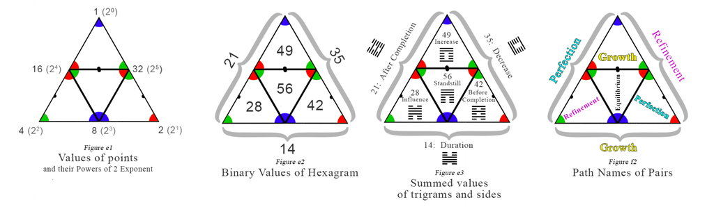

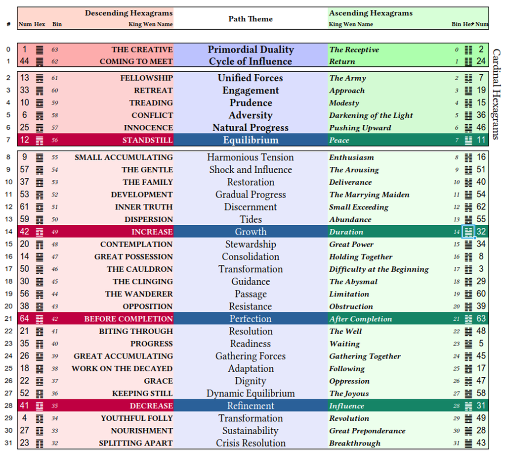

We can clearly see the relationship between the Parent and *Definition* axes symbolically represented by the hexagram pair 41䷨*<sub>35</sub>* *Decrease* (reduction, sacrifice) and 31䷞*<sub>28</sub>* *Influence* (harmonious joining) which, as previously noted, aligns perfectly with the underlying mathematics. This vector corresponds precisely to the path of *Refinement* that these two hexagrams embody, allowing us to state explicitly that refinement itself is fundamentally an act of definition and limitation.

The vector connecting Parent to *Contribution* aligns with the path of *Perfection*, represented by the archetypal hexagrams 63䷾*<sub>21</sub>* *After Completion* (balance, order, and harmony that has been successfully achieved), symbolizing the ideal of perfection, and its counterpart, 64䷿*<sub>42</sub>* *Before Completion* (transitioning to balance, order, and harmony), symbolizing the continual striving toward that ideal. These two hexagrams thus represent the complete spectrum of perfection, from aspiration to attainment.

Further, the vector linking *Definition* and *Contribution*, which, according to the Tholonic model, symbolizes the spectrum across which new instances of creation are instantiated, thus aptly named the axis of instantiation, corresponds directly to the path of *Growth*. This path is specifically defined by the hexagram pair 32䷟*<sub>14</sub>* *Duration* (stability, sustainability, endurance) and 42䷩*<sub>49</sub>* *Increase* (growth, expansion), providing as explicit and clear a definition of growth as can be found within the symbolic language of the I Ching.

At the heart of these interactions lies the central triad, embodying the path of *Equilibrium*, which we can also interpret as the *Balanced Path*.

This idea that the “way” or the “passage” is one of balance is reflected in the ancient truths of Buddhism’s *Middle Way*, Confucianism’s *Doctrine of the Mean*, Ancient Greek’s *Golden Mean*, Taoism’s *wu-wei*, Islam’s *wasatiyyah*, Judaism’s *shvil hazahav*, and in many indigenous traditions. Here, we’ll refer to the *Path of Equilibrium* as simply *The Passage*.

The Passage symbolizes the authentic and balanced way forward, represented powerfully by the cardinal pair of hexagrams 11䷊*<sub>7</sub>* *Peace* (balance, integration, flourishing) and 12䷋*<sub>56</sub>* *Standstill* (obstruction, blockage, disharmony).

### The Passage

The message of the *Path of Equilibrium* is clear: when Heaven and Earth unite harmoniously, peace arises; when they separate, stagnation inevitably follows.

In Tholonic terms, this profound insight reveals that when consciousness and intention focus on integrating the perfect archetype with its imperfect instances, in other words, seeing the perfection inherent within imperfection, Awareness and Intention manifest as growth via peace and harmony. Conversely, when consciousness and intention focus instead on separating the perfect archetype from its imperfect manifestations, that is, dwelling upon imperfection or lack, Awareness and Intention manifest as stagnation via disharmony and disintegration.